# What’s Your Malfunction?

Victoria Zdanowicz

10/19/2021

# Challenge 1

> Write a simple R function, Z.prop.test(), that can perform one- or two-sample Z-tests for proportion data, using the following guidelines:
- p1 and n1 (no default) representing the estimated proportion and sample size (i.e., based on your sample data); p2 and n2 (both defaulting to NULL) that contain a second sample’s proportion and sample size data in the event of a two-sample test; p0 (no default) as the expected value for the population proportion; and alternative (default “two.sided”) and conf.level (default 0.95), to be used in the same way as in the function t.test()
- When conducting a two-sample test, it should be p1 that is tested as being smaller or larger than p2 when alternative=“less” or alternative=“greater”, the same as in the use of x and y in the function t.test().
- The function should perform a one-sample Z-test using p1, n1, and p0 if either p2 or n2 (or both) is NULL.
- The function should contain a check for the rules of thumb we have talked about (n∗p>5 and n∗(1−p)>5) to ensure the validity of assuming the normal distribution in both the one- and two-sample settings. If this is violated, the function should still complete but it should also print an appropriate warning message.
- The function should return a list containing the members Z (the test statistic), P (the appropriate p value), and CI (the two-sided CI with respect to “conf.level” around p1 in the case of a one-sample test and around p2-p1 in the case of a two-sample test). For all test alternatives (“two.sided”, “greater”, “less”), calculate symmetric CIs based on quantiles of the normal distribution rather than worrying about calculating single-limit confidence bounds.

```r
library(dplyr)
library(curl)
```

```r
library(ggplot2)
library(gridExtra)
```

## My function - z.prop.test()

In order to figure out how to create this function I opened up the source code for the prop.test() function. This was extremely helpful in following along the syntax necessary ( **if** , **else** ) and other words needed to organize how the function runs. I found a hard time finding a website that clearly outlined the proper order/syntax to follow when creating a function - I also couldn’t find that in any of the modules?

```r
z.prop.test <- function(p1, n1, p2 = NULL, n2 = NULL, p0, alternative = "two.sided", conf.level = 0.95)
{

#one-sample test
if (is.null(p2)|is.null(n2)) {

  Z <- (p1 - p0) / sqrt(p0 * (1-p0)/n1) #calculating z-statistic

   #must consider test alternatives
    if (alternative == "less") {
      PVAL <- pnorm(Z, lower.tail = TRUE)
    }
    if (alternative == "greater") {
      PVAL <- pnorm(Z, lower.tail = FALSE)
    }
    if (alternative == "two.sided") {
      PVAL <- 1 - pnorm(Z, lower.tail = TRUE) + pnorm(Z, lower.tail = FALSE)
    }
        #checking validity of assuming normal distribution
        if ((n1 * p0 < 5) | (n1 * (1 - p0) < 5 )){
        message("Warning: check distribution, does not appear normal")
        }

  #calculating confidence interval
  lower <- p1 - qnorm(0.975) * sqrt(p1 * (1 - p1)/n1)
  upper <- p1 + qnorm(0.975) * sqrt(p1 * (1 - p1)/n1)
  ci <- c(lower, upper)

  #creating list of z-test results & print
  one.sample.prop <- list(test.type = "One-Sample Proportion Test", alternative = alternative, z.test.statistic = as.numeric(Z), p.value = as.numeric(PVAL), confidence.interval = ci)

  return(one.sample.prop)
          }

#two-sample test
else  {

  pstar <- ((p1*n1) + (p2*n2))/(n1 + n2) #need to multiply proportion by n to get sum for pooled proportion

  Z <- (p2 - p1)/sqrt((pstar * (1 - pstar)) * (1/n1 + 1/n2)) #calculating z-statistic

    #must consider test alternatives
    if (alternative == "less") {
      PVAL <- pnorm(Z, lower.tail = TRUE)
    }
    if (alternative == "greater") {
      PVAL <- pnorm(Z, lower.tail = FALSE)
    }
    if (alternative == "two.sided") {
      PVAL <- 1 - pnorm(Z, lower.tail = TRUE) + pnorm(Z, lower.tail = FALSE)
    }
        #checking validity of assuming normal distribution
        if ((n1 * p0 < 5) | (n1 * (1 - p0) < 5 ) | (n2 * p0 < 5) | (n2 * (1 - p0) < 5)){
        message("Warning: check distribution, does not appear normal")
}

  alpha = 1 - (conf.level)
  crit <- qnorm(1 - alpha/2)  # identify critical values
  test <- PVAL < -crit || PVAL > crit  # boolean test

  #calculating confidence interval
  upper <- (p1 - p2) + (crit) * (sqrt((p1*(1-p1)/n1) + (p2 * (1-p2)/n2)))
  lower <- (p1 - p2) - (crit) * (sqrt((p1*(1-p1)/n1) + (p2 * (1-p2)/n2)))
  ci <- c(lower, upper)

   #creating list of z-test results & print
  two.sample.prop <- list(test.type = "Two-Sample Proportion Test", alternative = alternative, z.test.statistic = as.numeric(Z), p.value = as.numeric(PVAL), confidence.interval = ci, critical.value = as.numeric(crit), test = test)

    return(two.sample.prop)
}}
```

## One-Sample Test

**Testing this function with sample data from module**

A neotropical ornithologist working in the western Amazon deploys 30 mist nets in a 100 hectare (ha) grid. She monitors the nets on one morning and records whether or not a she captures any birds in the net (i.e., a “success” or “failure” for every net during a netting session). The following vector summarizes her netting results:

```r
v <- c(0, 1, 1, 1, 0, 1, 0, 0, 1, 1, 0, 0, 1, 1, 0, 1, 1, 0, 0, 1, 1, 1, 0, 1, 1, 0, 1, 0, 1, 1)
```

Her netting success over the previous three seasons suggests that she should catch birds in **80%** of her nets. This season, she feels, her success rate is lower than in previous years. Does her trapping data support this hypothesis?

- p1 = 0.6
- n1 = 30
- p0 = 0.8

```r
z.prop.test(0.6, 30, p0 = 0.8, alternative = "less", conf.level = 0.95) #alternative = 'less' because testing if 0.8 is in lower tail
```

```
## $test.type
## [1] "One-Sample Proportion Test"
##
## $alternative
## [1] "less"
##
## $z.test.statistic
## [1] -2.738613
##
## $p.value
## [1] 0.00308495
##
## $confidence.interval
## [1] 0.4246955 0.7753045
```

These values match those from Module 10 and the p-value from the prop test below:

```r
ptest <- prop.test(x = sum(v), n = length(v), p = 0.8, conf.level = 0.95, correct = FALSE,
    alternative = "less")
ptest
```

```
##
##  1-sample proportions test without continuity correction
##
## data:  sum(v) out of length(v), null probability 0.8
## X-squared = 7.5, df = 1, p-value = 0.003085
## alternative hypothesis: true p is less than 0.8
## 95 percent confidence interval:
##  0.0000000 0.7328738
## sample estimates:
##   p
## 0.6
```

## Two-Sample Test

**Testing this function with sample data from module**

A biologist studying two species of tropical bats captures females of both species in a mist net over the course of week of nightly netting. For each species, the researcher records whether females are lactating or not. The two vectors below summarize the data for each species.

```r
v1 <- c(1, 0, 1, 1, 0, 0, 1, 1, 0, 0, 1, 1, 1, 1, 0, 0, 1, 1, 0, 0, 1, 1, 0, 1, 0)
v2 <- c(1, 1, 0, 0, 1, 1, 1, 1, 0, 1, 0, 1, 1, 1, 0, 1, 0, 1, 1, 1, 1, 1, 0, 0, 1, 1, 0, 1, 1, 1)
```

- phat1 = mean(v1) = p1 = 0.56
- n1 = length(v1) = 25
- phat2 = mean(v2) = p2 = 0.7
- n2 = length(v2) = 30

```r
z.prop.test(0.56, 25, 0.7, 30, p0 = 0, alternative = "two.sided", conf.level = 0.95)
```

```
## $test.type
## [1] "Two-Sample Proportion Test"
##
## $alternative
## [1] "two.sided"
##
## $z.test.statistic
## [1] 1.074709
##
## $p.value
## [1] 0.2825049
##
## $confidence.interval
## [1] -0.3944634  0.1144634
##
## $critical.value
## [1] 1.959964
##
## $test
## [1] FALSE
```

These values match those from Module 10 and the p-value from the prop test below…. I spent what felt like 10 years trying to figure out why my confidence intervals from z.prop.test were not the same at the prop.test ones when using the same example data. I realized I had the wrong CI formula, but even after I fixed that my intervals were opposite the ones in the module! I then *finally* realized it was because the vector data was entered opposite in the module.. meaning it was entered as **x = c(sum(v2),sum(v1))** which results in all the same variables as my function except the confidence intervals were inverted. So in the code below, using prop.test with the given data, I entered the data as **x = c(sum(v1)sum(v2))** which FINALLY yields the same confidence intervals!

```r
ptest2 <- prop.test(x = c(sum(v1), sum(v2)), n = c(length(v1), length(v2)), alternative = "two.sided",
    correct = FALSE)
ptest2
```

```
##
##  2-sample test for equality of proportions without continuity
##  correction
##
## data:  c(sum(v1), sum(v2)) out of c(length(v1), length(v2))
## X-squared = 1.155, df = 1, p-value = 0.2825
## alternative hypothesis: two.sided
## 95 percent confidence interval:
##  -0.3944634  0.1144634
## sample estimates:
## prop 1 prop 2
##   0.56   0.70
```

# Challenge 2

> The dataset from Kamilar and Cooper has in it a large number of variables related to life history and body size. For this exercise, the end aim is to fit a simple linear regression model to predict longevity (MaxLongevity_m) measured in months from species’ brain size (Brain_Size_Species_Mean) measured in grams. Do the following for both longevity~brain size and log(longevity)~log(brain size):
- Fit the regression model and, using {ggplot2}, produce a scatterplot with the fitted line superimposed upon the data. Append the the fitted model equation to your plot (HINT: use the function geom_text()).
- Identify and interpret the point estimate of the slope (β1), as well as the outcome of the test associated with the hypotheses H0: β1 = 0; HA: β1 ≠ 0. Also, find a 90 percent CI for the slope (β1) parameter.
- Using your model, add lines for the 90 percent confidence and prediction interval bands on the plot and add a legend to differentiate between the lines.

```r
f <- curl("https://raw.githubusercontent.com/fuzzyatelin/fuzzyatelin.github.io/master/AN588_Fall21/KamilarAndCooperData.csv")
d <- read.csv(f, header = TRUE, stringsAsFactors = FALSE)
head(d)
```

```
##               Scientific_Name          Family          Genus      Species
## 1 Allenopithecus_nigroviridis Cercopithecidae Allenopithecus nigroviridis
## 2         Allocebus_trichotis Cercopithecidae      Allocebus    trichotis
## 3           Alouatta_belzebul        Atelidae       Alouatta     belzebul
## 4             Alouatta_caraya        Atelidae       Alouatta       caraya
## 5            Alouatta_guariba        Atelidae       Alouatta      guariba
## 6           Alouatta_palliata        Atelidae       Alouatta     palliata
##   Brain_Size_Species_Mean Brain_Size_Female_Mean   Brain_size_Ref
## 1                   58.02                  53.70 Isler et al 2008
## 2                      NA                     NA
## 3                   52.84                  51.19 Isler et al 2008
## 4                   52.63                  47.80 Isler et al 2008
## 5                   51.70                  49.08 Isler et al 2008
## 6                   49.88                  48.04 Isler et al 2008
##   Body_mass_male_mean Body_mass_female_mean Mass_Dimorphism
```

[output cut: 62 more lines]

## Longevity~Brain Size

### Fitting the regression model

I first cleaned the data, removing any NA/missing values to avoid calculation errors. I also pulled out the desired *predictor* and *response* variable data into objects **x** and **y**.

```r
d <- na.omit(d)

x <- d$Brain_Size_Species_Mean #predictor
y <- d$MaxLongevity_m #response
```

I then used the code from Module 11 to determine the regression slope(beta1) and intercept(beta0)

```r
beta1 <- cor(y, x) * sd(y)/sd(x)
beta0 <- mean(y) - beta1 * mean(x)

beta.values <- list(Slope = as.numeric(beta1), Intercept = as.numeric(beta0))
print(beta.values)
```

```
## $Slope
## [1] 0.8789037
##
## $Intercept
## [1] 307.7522
```

You can then use the beta values and the predictor data, **x**, to determine the regression line. The regression line equation is: y = beta1(x)+beta0… aka *y = slope(x) + intercept*

```r
yhat.regression <- beta1 * x + beta0
yhat.regression
```

```
##  [1] 351.5919 356.2853 314.1155 371.8507 370.4444 373.1339 372.6417 330.4016
##  [9] 325.4797 738.7754 397.2861 392.5664 390.3428 363.9845 398.2090 389.6660
## [17] 631.4964 454.8983 451.1805 436.2216 639.4329 314.7307 405.2490 416.2968
## [25] 424.9364 335.9826
```

```r
Regression.equation <- paste("y = ",beta1, "* x + ", beta0)
Regression.equation
```

```
## [1] "y =  0.878903694312715 * x +  307.752215122644"
```

Can also determine regression using lm() function, which is much faster/cleaner…

```r
m <- lm(y ~ x, data = d)
summary(m)
```

```
##
## Call:
## lm(formula = y ~ x, data = d)
##
## Residuals:
##      Min       1Q   Median       3Q      Max
## -152.498  -73.422   -4.425   72.430  285.749
##
## Coefficients:
##             Estimate Std. Error t value Pr(>|t|)
## (Intercept) 307.7522    27.8459  11.052 6.73e-11 ***
## x             0.8789     0.1672   5.256 2.18e-05 ***
## ---
## Signif. codes:  0 '***' 0.001 '**' 0.01 '*' 0.05 '.' 0.1 ' ' 1
##
## Residual standard error: 98.31 on 24 degrees of freedom
## Multiple R-squared:  0.5351, Adjusted R-squared:  0.5158
## F-statistic: 27.63 on 1 and 24 DF,  p-value: 2.176e-05
```

Next - I used used ggplot to create a scatterplot with the fitted regression line superimposed upon the data. I added the regression equation based on the object *Regression.equation* I made above.

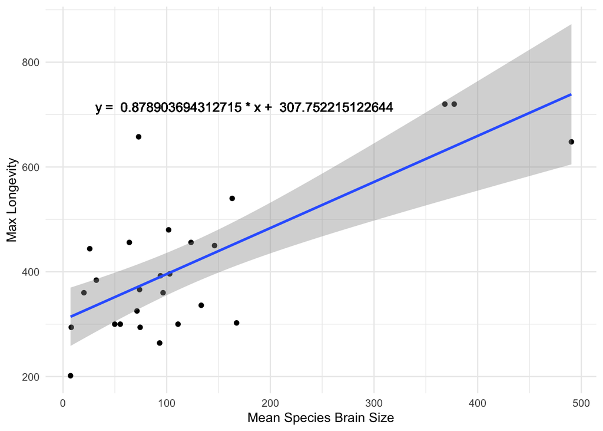

```r
plot1a <- ggplot(data = d, aes(x = x, y = y)) + theme_minimal() +
            geom_point() +
            labs(x = "Mean Species Brain Size", y = "Max Longevity", size = 14) +
            geom_smooth(method = "lm", formula = y ~ x) +
            geom_text(x = 175, y = 715, label= Regression.equation)
plot1a
```

I found another way to get the equation by installing the package (ggpmisc), which I found on Stack Overflow (https://stackoverflow.com/questions/7549694/add-regression-line-equation-and-r2-on-graph) when trying to figure out how to show the regression equation on the plot. With this package, I can use *stat_poly_eq()* to label the line equation of my formula *y ~ x* .

```r
library(ggpmisc)
```

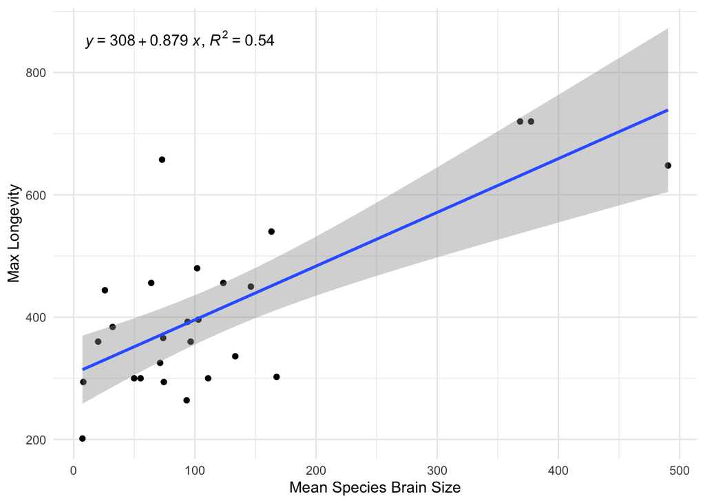

```r
plot1b <- ggplot(data = d, aes(x = x, y = y)) + theme_minimal() +
            geom_point() +
            labs(x = "Mean Species Brain Size", y = "Max Longevity", size = 14) +
            geom_smooth(method = "lm", formula = y ~ x) +
            stat_poly_eq(formula = y ~ x, aes(label = paste(..eq.label.., ..rr.label.., sep = "*plain(\",\")~")), parse = TRUE)
plot1b
```

### Identify & Interpret

As outlined above..

Slope = beta1 = cor(y, x) * sd(y)/sd(x)

Intercept = beta0 = mean(y) - beta1 * mean(x)

```r
beta.values
```

```
## $Slope
## [1] 0.8789037
##
## $Intercept
## [1] 307.7522
```

Below is the 90 CI for the slope (β1) parameter.

```r
beta1.ci <- confint(m, level = 0.90)  #confint() function uses lm object "m" to calculate confidence intervals.
beta1.ci
```

```
##                     5 %       95 %
## (Intercept) 260.1112167 355.393214
## x             0.5928154   1.164992
```

### Adding Confidence & Prediction Intervals

I first created 90% confidence intervals using predict() function from Module 11.

```r
ci90 <- predict(m, newdata = data.frame(Brain_Size_Species_Mean = x), interval = "confidence",level = 0.90)
colnames(ci90) <- c("Fit_CI","Lower_CI","Upper_CI")
head(ci90)
```

```
##     Fit_CI Lower_CI Upper_CI
## 1 351.5919 312.9621 390.2217
## 2 356.2853 318.4280 394.1425
## 3 314.1155 267.9467 360.2843
## 4 371.8507 336.2051 407.4962
## 5 370.4444 334.6229 406.2659
## 6 373.1339 337.6445 408.6232
```

Next I created 90% predictive intervals using predict() with the argument interval = “prediction”

```r
pi90 <- predict(m, newdata = data.frame(Brain_Size_Species_Mean = x), interval = "prediction", level = 0.90)
colnames(pi90) <- c("Fit_PI","Lower_PI","Upper_PI")
head(pi90)
```

```
##     Fit_PI Lower_PI Upper_PI
## 1 351.5919 179.0151 524.1688
## 2 356.2853 183.8797 528.6908
## 3 314.1155 139.6963 488.5347
## 4 371.8507 199.9172 543.7841
## 5 370.4444 198.4744 542.4144
## 6 373.1339 201.2328 545.0350
```

I then used cbind() to coerce the confidence and prediction intervals, and longevity and brain size data, into a single dataframe, *interval.plot*

```r
interval.plot <- data.frame(cbind(x, y, ci90, pi90))
head(interval.plot)
```

```
##       x     y   Fit_CI Lower_CI Upper_CI   Fit_PI Lower_PI Upper_PI
## 1 49.88 300.0 351.5919 312.9621 390.2217 351.5919 179.0151 524.1688
## 2 55.22 300.0 356.2853 318.4280 394.1425 356.2853 183.8797 528.6908
## 3  7.24 201.6 314.1155 267.9467 360.2843 314.1155 139.6963 488.5347
## 4 72.93 657.6 371.8507 336.2051 407.4962 371.8507 199.9172 543.7841
## 5 71.33 325.2 370.4444 334.6229 406.2659 370.4444 198.4744 542.4144
## 6 74.39 294.0 373.1339 337.6445 408.6232 373.1339 201.2328 545.0350
```

### Plotting PI/CI

Next, using ggplot, I created a new scatterplot with the 90% Confidence and Prediction Intervals. By using ‘color = “Confience”/“Prediction”’ I was able to separate the colors for the Prediction and Confidence intervals in the legend.

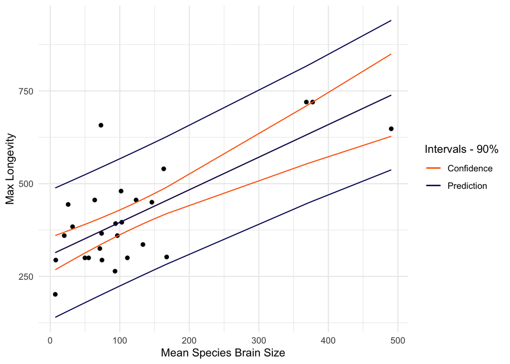

```r
plot2 <- ggplot(interval.plot, aes(x = x, y = y)) + theme_minimal() +
          geom_point() + labs(x = "Mean Species Brain Size", y = "Max Longevity", size = 14) +
          geom_line(aes(x = x, y = Fit_CI, color = "Confidence")) +
          geom_line(aes(x = x, y = Lower_CI, color = "Confidence")) +
          geom_line(aes(x = x, y = Upper_CI, color = "Confidence")) +
          geom_line(aes(x = x, y = Fit_PI, color = "Prediction")) +
          geom_line(aes(x = x, y = Lower_PI, color = "Prediction")) +
          geom_line(aes(x = x, y = Upper_PI, color = "Prediction")) +
        scale_color_manual(name = "Intervals - 90%", values=c("Confidence" = "#FF6600", "Prediction" = "#000066")) #spooky colors !!

plot2
```

```r
pt.est <- predict(m, newdata = data.frame(x = 800))
pt.est
```

```
##        1
## 1010.875
```

*pt.est* is the single value predicted based on the linear regression, m, (plugging x = 800 into regression line equation). I would not trust this value given the fact that the data in our plots are condensed mostly under 200g, with only 3 points falling above. There is thus little data to strongly support the model beyond 500g.

## Log(longevity) ~ Log(brain size)

### Fitting the log regression model

Like before, I pulled out the desired *predictor* and *response* variable data from dataframe, d, (with NA/missing values already removed) into objects **xx** and **yy**. During this process, I also transformed the data with function log()

```r
xx <- log(d$Brain_Size_Species_Mean) #log(predictor)
yy <- log(d$MaxLongevity_m) #log(response)
```

Using the same code as earlier, only this time with variables **xx** and **yy**, I determined the regression slope(log.beta1) and intercept(log.beta2)

```r
log.beta1 <- cor(yy, xx) * sd(yy)/sd(xx)
log.beta0 <- mean(yy) - log.beta1 * mean(xx)

log.beta.values <- list(Slope = as.numeric(log.beta1), Intercept = as.numeric(log.beta0))
print(log.beta.values)
```

```
## $Slope
## [1] 0.2028543
##
## $Intercept
## [1] 5.086498
```

You can then use the log beta values and the log predictor data, **xx**, to determine the regression line. The regression line equation is: yy = beta1(xx)+beta0… aka *y = slope(x) + intercept*

```r
yy.log <- log.beta1 * xx + log.beta0
yy.log
```

```
##  [1] 5.879581 5.900212 5.488072 5.956641 5.952141 5.960662 5.959129 5.745614
##  [9] 5.695912 6.343229 6.024435 6.013449 6.008060 5.930082 6.026515 6.006391
## [17] 6.285171 6.125214 6.120023 6.097680 6.290083 5.506794 6.041718 6.063493
## [25] 6.079029 5.790296
```

```r
log.equation <- paste("yy = ",log.beta1, "* xx + ", log.beta0) #I used paste() here to show the regression line equation
log.equation
```

```
## [1] "yy =  0.202854284674617 * xx +  5.08649774633527"
```

lm() is, again, a much faster way to determine the regression line.

```r
logm <- lm(yy ~ xx, data = d)
summary(logm)
```

```
##
## Call:
## lm(formula = yy ~ xx, data = d)
##
## Residuals:
##      Min       1Q   Median       3Q      Max
## -0.43044 -0.18029 -0.01211  0.17548  0.53196
##
## Coefficients:
##             Estimate Std. Error t value Pr(>|t|)
## (Intercept)  5.08650    0.22413  22.694  < 2e-16 ***
## xx           0.20285    0.05002   4.055 0.000458 ***
## ---
## Signif. codes:  0 '***' 0.001 '**' 0.01 '*' 0.05 '.' 0.1 ' ' 1
##
## Residual standard error: 0.2539 on 24 degrees of freedom
## Multiple R-squared:  0.4066, Adjusted R-squared:  0.3819
## F-statistic: 16.44 on 1 and 24 DF,  p-value: 0.0004583
```

From *summary(logm)* we see that the p-value, (0.000458), is less than 0.05 and thus, the predictor variable (brain size) significantly influences the response variable (max longevity). This means we can reject the null hypothesis..

Next - I used used ggplot to create a scatterplot with the fitted log regression line superimposed upon the data. I added the regression equation based on the object *log.equation* I made above with the equation components.

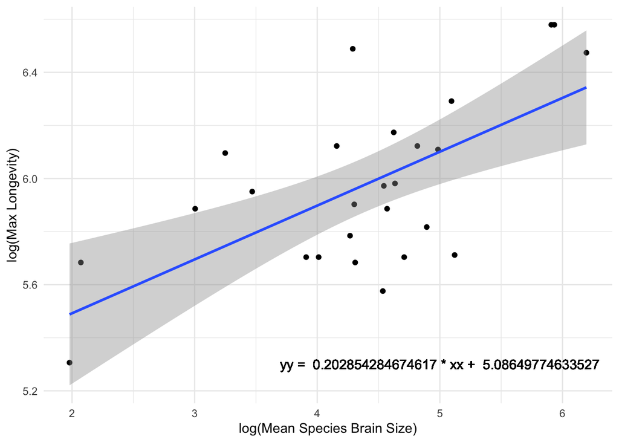

```r
log.plot1 <- ggplot(data = d, aes(x = xx, y = yy)) + theme_minimal() +
              geom_point() +
              labs(x = "log(Mean Species Brain Size)", y = "log(Max Longevity)", size = 14) +
              geom_smooth(method = "lm", formula = y ~ x) +
              geom_text(x = 5, y = 5.3, label= log.equation)
log.plot1
```

### Identify & Interpret (log)

As outlined above..

Slope = log.beta1 = cor(yy, xx) * sd(yy)/sd(xx)

Intercept = log.beta0 = mean(yy) - log.beta1 * mean(xx)

```r
log.beta.values
```

```
## $Slope
## [1] 0.2028543
##
## $Intercept
## [1] 5.086498
```

*The log transformed data looks at percentage of difference without the different units (grams and months) confounding our analysis.*

Below is the 90 CI for the log slope (β1) parameter.

```r
log.beta1.ci <- confint(logm, level = 0.90)  #confint() function uses lm object "logm" to calculate confidence intervals.
log.beta1.ci
```

```
##                   5 %      95 %
## (Intercept) 4.7030309 5.4699646
## xx          0.1172695 0.2884391
```

### Adding Confidence & Prediction Intervals (log)

I first created 90% confidence intervals using predict() function from Module 11. *data = logm here instead of m*

```r
log.ci90 <- predict(logm, newdata = data.frame(Brain_Size_Species_Mean = xx), interval = "confidence",level = 0.90)
colnames(log.ci90) <- c("Fit_CI","Lower_CI","Upper_CI")
head(log.ci90)
```

```
##     Fit_CI Lower_CI Upper_CI
## 1 5.879581 5.785763 5.973399
## 2 5.900212 5.809692 5.990732
## 3 5.488072 5.266574 5.709571
## 4 5.956641 5.871172 6.042110
## 5 5.952141 5.866501 6.037781
## 6 5.960662 5.875311 6.046013
```

Next I created 90% predictive intervals using predict() with the argument interval = “prediction”

```r
log.pi90 <- predict(logm, newdata = data.frame(Brain_Size_Species_Mean = xx), interval = "prediction", level = 0.90)
colnames(log.pi90) <- c("Fit_PI","Lower_PI","Upper_PI")
head(log.pi90)
```

```
##     Fit_PI Lower_PI Upper_PI
## 1 5.879581 5.435127 6.324035
## 2 5.900212 5.456443 6.343982
## 3 5.488072 5.000426 5.975719
## 4 5.956641 5.513874 6.399408
## 5 5.952141 5.509341 6.394941
## 6 5.960662 5.517918 6.403406
```

I then used cbind() to coerce the confidence and prediction intervals, and log(longevity) and log(brain size) data, into a single dataframe, *log.interval.plot*

```r
log.interval.plot <- data.frame(cbind(xx, yy, log.ci90, log.pi90))
head(log.interval.plot)
```

```
##         xx       yy   Fit_CI Lower_CI Upper_CI   Fit_PI Lower_PI Upper_PI
## 1 3.909620 5.703782 5.879581 5.785763 5.973399 5.879581 5.435127 6.324035
## 2 4.011325 5.703782 5.900212 5.809692 5.990732 5.900212 5.456443 6.343982
## 3 1.979621 5.306286 5.488072 5.266574 5.709571 5.488072 5.000426 5.975719
## 4 4.289500 6.488597 5.956641 5.871172 6.042110 5.956641 5.513874 6.399408
## 5 4.267317 5.784440 5.952141 5.866501 6.037781 5.952141 5.509341 6.394941
## 6 4.309322 5.683580 5.960662 5.875311 6.046013 5.960662 5.517918 6.403406
```

### Plotting log PI/CI

Next, using ggplot, I created a new scatterplot with the 90% Confidence and Prediction Intervals. By using ‘color = “Confience”/“Prediction”’ I was able to separate the colors for the Prediction and Confidence intervals in the legend.

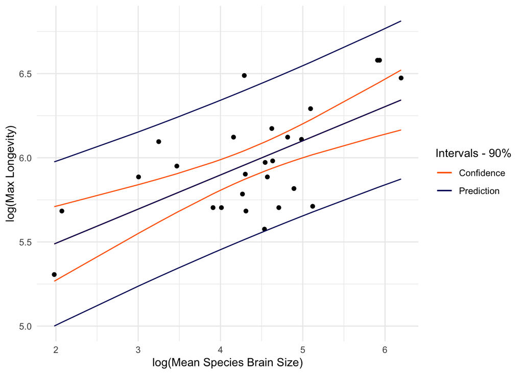

```r
log.plot2 <- ggplot(log.interval.plot, aes(x = xx, y = yy)) + theme_minimal() +
          geom_point() + labs(x = "log(Mean Species Brain Size)", y = "log(Max Longevity)", size = 14) +
          geom_line(aes(x = xx, y = Fit_CI, color = "Confidence")) +
          geom_line(aes(x = xx, y = Lower_CI, color = "Confidence")) +
          geom_line(aes(x = xx, y = Upper_CI, color = "Confidence")) +
          geom_line(aes(x = xx, y = Fit_PI, color = "Prediction")) +
          geom_line(aes(x = xx, y = Lower_PI, color = "Prediction")) +
          geom_line(aes(x = xx, y = Upper_PI, color = "Prediction")) +
        scale_color_manual(name = "Intervals - 90%", values=c("Confidence" = "#FF6600", "Prediction" = "#000066")) #spooky colors !!

log.plot2
```

```r
log.pt.est <- predict(logm, newdata = data.frame(xx = log(800)))
log.pt.est
```

```
##      1
## 6.4425
```

*pt.est*is the single value predicted based on the linear regression, m, (plugging xx = log(800) into regression line equation). Because the data was log transformed, the predicted value, 6.4425, is much closer to the known data. You can also see the confidence intervals in the log estimate are much closer to the fit lines, suggesting it is a better representative model.

## Comparing the Models

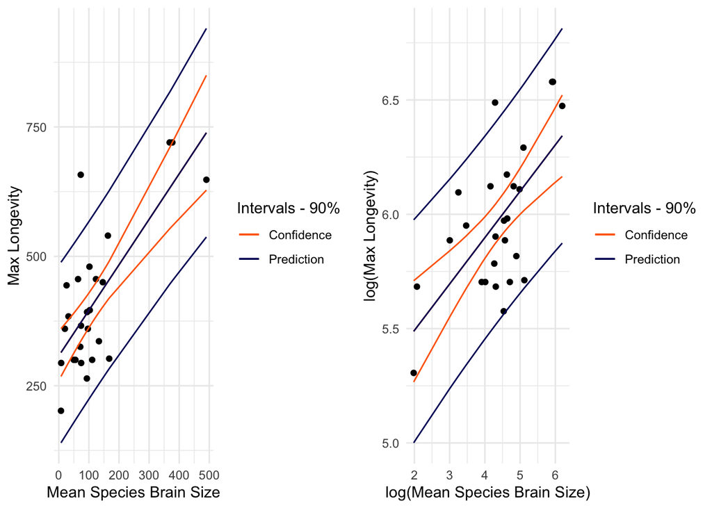

```r
grid.arrange(plot2, log.plot2, nrow = 1)
```

```r
summary(m)
```

```
##
## Call:
## lm(formula = y ~ x, data = d)
##
## Residuals:
##      Min       1Q   Median       3Q      Max
## -152.498  -73.422   -4.425   72.430  285.749
##
## Coefficients:
##             Estimate Std. Error t value Pr(>|t|)
## (Intercept) 307.7522    27.8459  11.052 6.73e-11 ***
## x             0.8789     0.1672   5.256 2.18e-05 ***
## ---
## Signif. codes:  0 '***' 0.001 '**' 0.01 '*' 0.05 '.' 0.1 ' ' 1
##
## Residual standard error: 98.31 on 24 degrees of freedom
## Multiple R-squared:  0.5351, Adjusted R-squared:  0.5158
## F-statistic: 27.63 on 1 and 24 DF,  p-value: 2.176e-05
```

```r
summary(logm)
```

```
##
## Call:
## lm(formula = yy ~ xx, data = d)
##
## Residuals:
##      Min       1Q   Median       3Q      Max
## -0.43044 -0.18029 -0.01211  0.17548  0.53196
##
## Coefficients:
##             Estimate Std. Error t value Pr(>|t|)
## (Intercept)  5.08650    0.22413  22.694  < 2e-16 ***
## xx           0.20285    0.05002   4.055 0.000458 ***
## ---
## Signif. codes:  0 '***' 0.001 '**' 0.01 '*' 0.05 '.' 0.1 ' ' 1
##
## Residual standard error: 0.2539 on 24 degrees of freedom
## Multiple R-squared:  0.4066, Adjusted R-squared:  0.3819
## F-statistic: 16.44 on 1 and 24 DF,  p-value: 0.0004583
```

## Challenges

1. This homework took *so* much brain power. I had a hard time getting started with the function building, especially because I only really understood the basic functions we had gone over in class without really getting the proper syntax/arguments. So it took me a while to figure out the right language to use when it came to *else* and *if*. I figured out how to look at the prop.test() source code though, which was **extremely** helpful at understanding the syntax of a complex function.
2. It took a lot of trial and error of running my code chunks to see where I was screwing up the curly brackets and parentheses for my function.. but again, after opening the source code I had an easier time with that.
3. This assignment felt very different in the sense that I had a really hard time working in the markdown file! I ended up opening up an R.script file to try and work through my function. I found it a bit easier to just mess around with the order of things there as opposed to in the markdown file where I had text explaining my thought process and other code snippets I was pasting and saving for later.
4. While opening the prop.test() source code was helpful in many ways, it also made things a *bit* more confusing at times since we were asked to create a function with different variables in the argument than what is included in the prop.test function argument. It took me a while to think through how each step would be modified based on the variables provided in the argument. At one point - I even was writing on scrap paper to make sure the transformation of my variables made sense!
5. Lastly, it was not until peer review that I fully realized the confidence intervals and prediction intervals were different things. It makes a lot of sense now that I went back over Module 11 about two hundred times during the course of this assignment lol. But I for some reason thought the PI in the homework question was a typo.. embarrassing. Once I figured that out though, I felt like I began to really understand how to assess the models and what the predict() function was doing.
6. ALSO - two sample proportion confidence intervals… I am not totally confident that I figured those out correctly. In peer review, we cross-referenced a ton of different online equations and I *think* what we did worked.. but I am not entirely sold on Z in the equation…actually I just went back and changed it again, I think the Z* in a lot of the equations Ive looked at is supposed to be the critical value. So I just updated the function to use the critical value *crit* instead of the z-test statistic value. https://stats.libretexts.org/Bookshelves/Introductory_Statistics/Book%3A_Statistics_Using_Technology_(Kozak)/09%3A_Two-Sample_Interference/9.01%3A_Two_Proportions

**the end**